# Raport PD4 - mapa

Helena Wałachowska

2023-04-03

## Tematyka

Zaprezentowana wizualzacja miała na celu przedstawienie relacji między urbanizacją danego stanu USA, a liczbą wykrytych morderst przypadających na 100.000 mieszkańców danego stanu. Dane pochodzą z roku 1973.

## Dane

Dane zostały zaczerpnięte ze strony [kaggle.com](https://www.kaggle.com/datasets/mathchi/violent-crime-rates-by-us-state).

## Wizualizacja

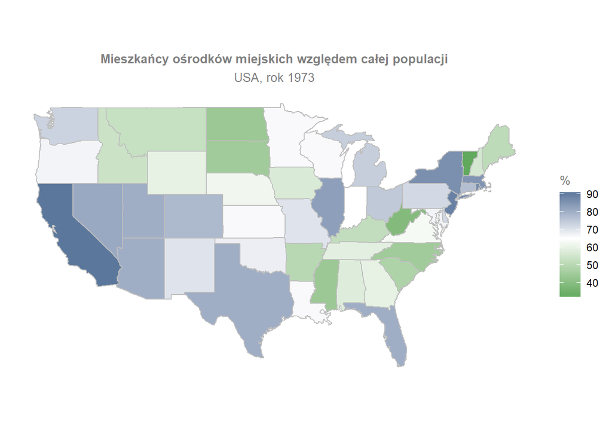

```r
library(ggplot2)
library(maps)
library(mapdata)
library(dplyr)
library(patchwork)

crime <- read.csv("US_violent_crime.csv")

df <- crime %>%
  mutate(X = tolower(X))

states <- map_data("state")

# tabelki do wykresów

murder <- df %>%
  select(X, Murder) %>%
  full_join(states, by = c("X" = "region"))

urban_pop <- df %>%
  select(X, UrbanPop) %>%
  full_join(states, by = c("X" = "region"))

theme_nothing <- theme(
  axis.text = element_blank(),
  axis.line = element_blank(),
  axis.ticks = element_blank(),
  panel.border = element_blank(),
  panel.grid = element_blank(),
  axis.title = element_blank()
)

# wykresy

murder_map <- ggplot(data = murder)+
  geom_polygon(aes(x = long, y = lat, group = group, fill = Murder), color = "grey", ) +
  coord_fixed(1.3) +
  scale_fill_gradient2(
    low = "#5584B0",
    mid = "white",
    high = "#BF233C",
    midpoint = 10,
    space = "Lab",
    na.value = "grey50",
    guide = "colourbar",
    aesthetics = "fill"
  ) +
  theme_bw() +
  theme_nothing +
  labs(title = "Liczba morderstw na 100.000 mieszkańców",
       subtitle = "USA, rok 1973",
       fill = "Morderstwa") +
  theme(plot.title=element_text(face = "bold", size = 10, hjust = 0.5, color = "grey50"),
        plot.subtitle = element_text(size = 10, hjust = 0.5, color = "grey50"),
        legend.title = element_text(size = 10, color = "grey50"))


urban_map <- ggplot(data = urban_pop)+
  geom_polygon(aes(x = long, y = lat, group = group, fill = UrbanPop), color = "grey", ) +
  scale_fill_gradient2(
    low = "#61A95C",
    mid = "white",
    high = "#2A5783",
    midpoint = 65,
    space = "Lab",
    na.value = "grey50",
    guide = "colourbar",
    aesthetics = "fill"
  ) +
  coord_fixed(1.3) +
  theme_bw() +
  theme_nothing +
  labs(title = "Mieszkańcy ośrodków miejskich względem całej populacji",
       subtitle = "USA, rok 1973",
       fill = "%") +
  theme(plot.title=element_text(face = "bold", size = 10, hjust = 0.5, color = "grey50"),
        plot.subtitle = element_text(size = 10, hjust = 0.5, color = "grey50"),
        legend.title = element_text(size = 10, color = "grey50"))

urban_map
```

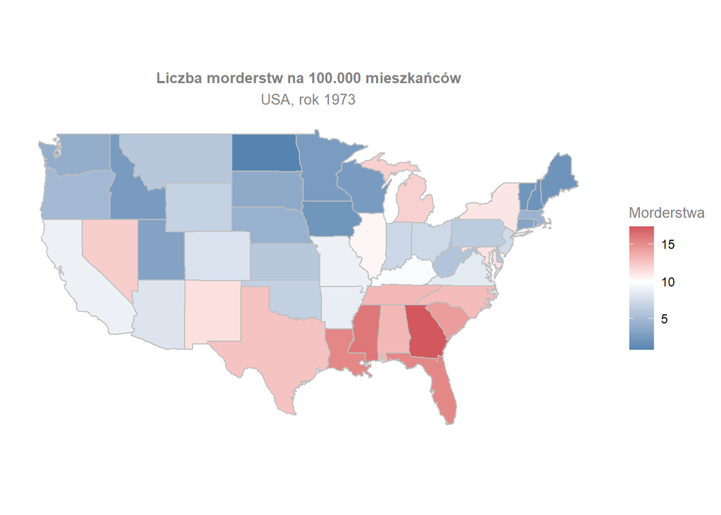

```r
murder_map
```

## Wnioski

Po analizie obu map możemy stwierdzić, że sytuacja w każdym ze stanów jest odmienna i trudno byłoby określić jednoznaczną regułę wiążącą ze sobą oba zjawiska.

Możemy wyróżnić 4 zwracające uwagę kategorie:

- stany o wysokim współczynniku morderstw i wysokim stopniu urbanizacji, tutaj wyróżnia się Floryda, potem dostrzegamy Texas, Nevadę i Michigan, w których proporcja pomiędzy współczynnikami jest zachowana, ale ich wartości są niższe niż na Florydzie, w Nowym Yorku mimo prawie najwyższej urbanizacji również odnotowano znaczącą liczbę morderstw;
- stany o wysokim współczynniku morderstw i niewielkim stopniu urbanizacji, w tej kategorii znajduje się większość stanów południowo-wschodnich Tennesse, Karolina Pn. i Pd., Missipi, Alabama oraz Georgia, którą wyróżnia największy współczynnik zabójstw;
- stany o niskim współczynniku morderstw i niewielkim stopniu urbanizacji, w tym przypadku są to stany północno-zachodnie, gdzie wyróżniają się Dakota Pn. i Pd., Idaho i Iowa, bardzo pozytywnie w tej kategorii wypadają stany najdalej wysunięte na północny-wschód, czyli Vermont, New Hampshire i Maine;
- stany o niskim współczynniku morderstw i znaczącym stopniu urbanizacji, tu przodują małe stany północno-wschodnie: Massachusetts, Connecticut, Rhode Island, a z drugiej strony duże stany zachodnie takie jak: Utah, Oregon i Waszyngton.